# Forecasting Consumer price index

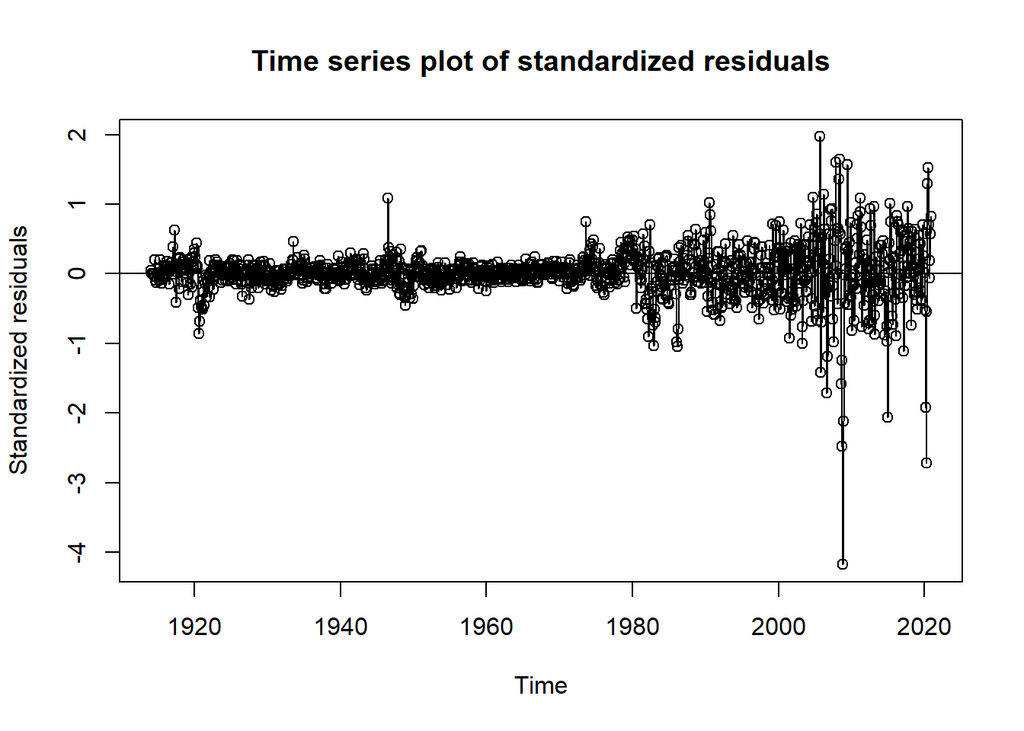

```r
plot(holtsmodelresiduals,type='o',ylab='Standardized residuals', main="Time series plot of standardized residuals")
  abline(h=0)
```

**Forecast and Accuracy of Holt-Winters Model**

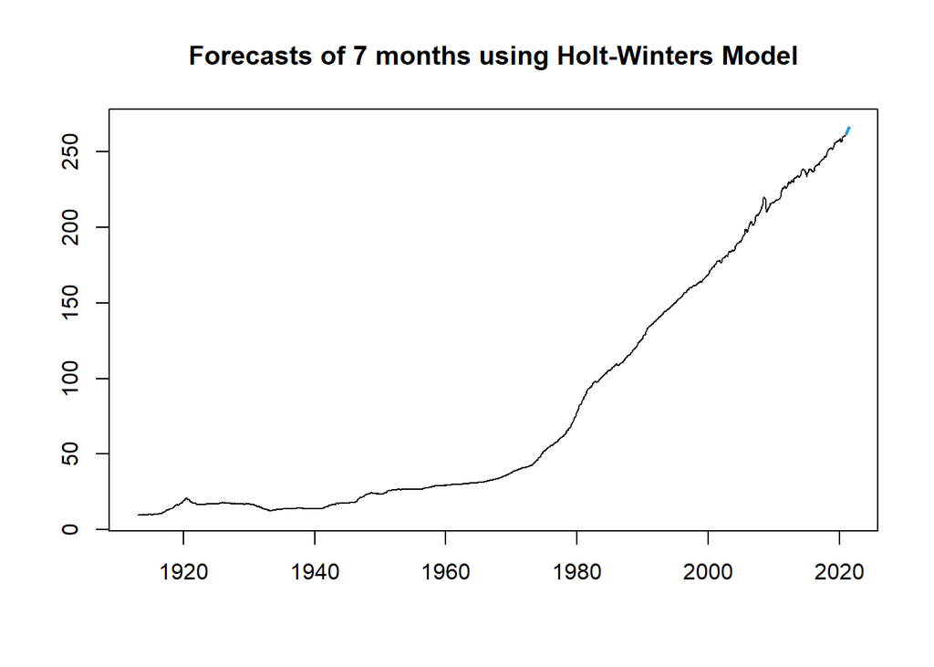

```r
# Forecast future values
holtsforecast <- forecast(holtsmodel, h = 7)  # Adjust "h" to the desired number of future periods to forecast

# Plot the forecasts
plot(holtsforecast, main = "Forecasts of 7 months using Holt-Winters Model")
```

```r
#Accuracy Test
holtsaccuracy <- accuracy(holtsforecast, test$CPI)
print(holtsaccuracy)
```

```
##                       ME      RMSE       MAE        MPE      MAPE      MASE
## Training set 0.007158537 0.3689689 0.2179098 0.02978742 0.4083987  0.755586
## Test set     3.089489083 4.0073039 3.0894891 1.14241420 1.1424142 10.712572
##                   ACF1
## Training set 0.4985787
## Test set            NA
```

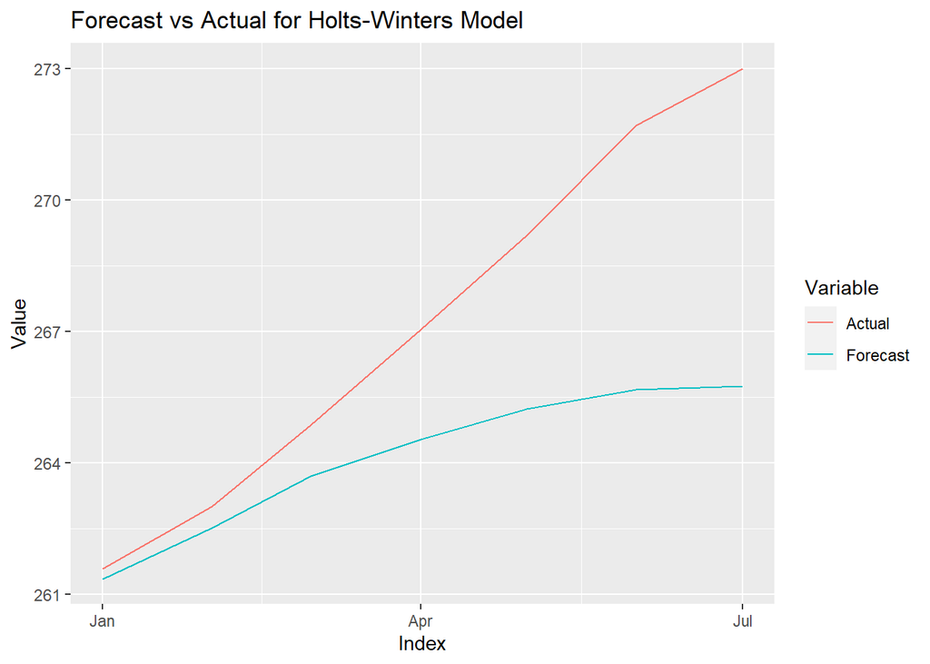

```r
# Create a data frame with forecasted values and actual values
dfholts <- data.frame(
  Index = test$Yearmon,
  Value = c(holtsforecast$mean, test$CPI),
  Variable = rep(c("Forecast", "Actual"), each = length(holtsforecast$mean))
)

# Plot the data frame
ggplot(dfholts, aes(x = Index, y = Value, color = Variable)) +
  geom_line() +
  labs(x = "Index", y = "Value", color = "Variable",title = "Forecast vs Actual for Holts-Winters Model")
```

```r
summary(holtsmodel)
```

```
##              Length Class  Mode
## fitted       5136   mts    numeric
## x            1296   ts     numeric
## alpha           1   -none- numeric
## beta            1   -none- numeric
## gamma           1   -none- numeric
## coefficients   14   -none- numeric
## seasonal        1   -none- character
## SSE             1   -none- numeric
## call            3   -none- call
```

**ARMA and GARCH combination**

GARCH models are specifically designed to handle heteroskedasticity. These models allow for the variance of the errors to be time-varying. This can help to improve the accuracy of the model’s predictions.

For the assumptions, we already know that the differenced_ts is trend stationary.

The accuracy scores are still not as good as the holt-winters model.

```r
library(fGarch)
# Fit GARCH ARMA model
garch_model <- garchFit(~ arma(1, 1) + garch(1, 1), data = differenced_ts, trace = FALSE)

# Forecast next 7 data points
forecast_garch <- predict(garch_model, n.ahead = 6)

# Obtain the original scale forecasts by applying inverse differencing
forecast_garchvalues <- diffinv(forecast_garch$meanForecast, xi = tail(traints, 1))

# Print the forecasted values
print(forecast_garchvalues)
```

```
## [1] 273.0030 274.3892 275.7500 277.0861 278.3978 279.6857 280.9503
```

```r
#Accuracy Test
accuracy4 <- accuracy(forecast_garchvalues, test$CPI)
print(accuracy4)
```

```
##                 ME     RMSE      MAE       MPE     MAPE
## Test set -9.834444 9.931091 9.834444 -3.688994 3.688994
```

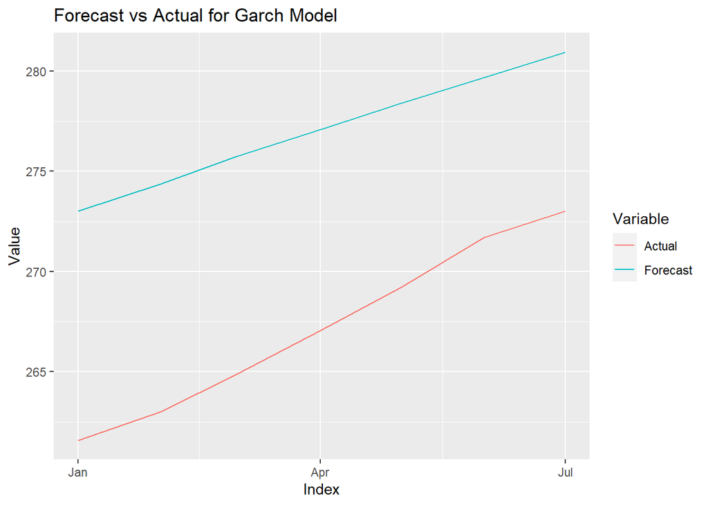

```r
# Create a data frame with forecasted values and actual values
dfgarch <- data.frame(
  Index = test$Yearmon,
  Value = c(forecast_garchvalues, test$CPI),
  Variable = rep(c("Forecast", "Actual"), each = length(forecast_garchvalues))
)

# Plot the data frame
ggplot(dfgarch, aes(x = Index, y = Value, color = Variable)) +
  geom_line() +
  labs(x = "Index", y = "Value", color = "Variable",title = "Forecast vs Actual for Garch Model")
```

```r
#plot(garch_model)


shapiro.test(garch_model@residuals)
```

```
##
##  Shapiro-Wilk normality test
##
## data:  garch_model@residuals
## W = 0.78932, p-value < 2.2e-16
```

```r
summary(garch_model)
```

```
##
## Title:
##  GARCH Modelling
##
## Call:
##  garchFit(formula = ~arma(1, 1) + garch(1, 1), data = differenced_ts,
##     trace = FALSE)
##
## Mean and Variance Equation:
##  data ~ arma(1, 1) + garch(1, 1)
## <environment: 0x00000000297190b0>
##  [data = differenced_ts]
##
## Conditional Distribution:
##  norm
##
## Coefficient(s):
##          mu          ar1          ma1        omega       alpha1        beta1
##  0.00175732   0.98048370  -0.79839864   0.00049521   0.20891911   0.81272157
##
## Std. Errors:
##  based on Hessian
##
## Error Analysis:
##          Estimate  Std. Error  t value Pr(>|t|)
## mu      0.0017573   0.0008933    1.967   0.0492 *
## ar1     0.9804837   0.0079428  123.443  < 2e-16 ***
## ma1    -0.7983986   0.0303137  -26.338  < 2e-16 ***
## omega   0.0004952   0.0001235    4.011 6.05e-05 ***
## alpha1  0.2089191   0.0277248    7.535 4.86e-14 ***
## beta1   0.8127216   0.0208652   38.951  < 2e-16 ***
## ---
## Signif. codes:  0 '***' 0.001 '**' 0.01 '*' 0.05 '.' 0.1 ' ' 1
##
## Log Likelihood:
##  226.2685    normalized:  0.1737853
##
## Description:
##  Thu May 25 03:47:54 2023 by user: Bimal
##
##
## Standardised Residuals Tests:
##                                 Statistic p-Value
##  Jarque-Bera Test   R    Chi^2  1531.57   0
##  Shapiro-Wilk Test  R    W      0.9642424 0
##  Ljung-Box Test     R    Q(10)  60.71117  2.657926e-09
##  Ljung-Box Test     R    Q(15)  113.6809  0
##  Ljung-Box Test     R    Q(20)  118.9395  4.440892e-16
##  Ljung-Box Test     R^2  Q(10)  5.610475  0.8468595
##  Ljung-Box Test     R^2  Q(15)  6.762879  0.9638986
##  Ljung-Box Test     R^2  Q(20)  8.05414   0.9915035
##  LM Arch Test       R    TR^2   6.005126  0.9158235
##
## Information Criterion Statistics:
##        AIC        BIC        SIC       HQIC
## -0.3383541 -0.3145215 -0.3383963 -0.3294127
```

**SARIMA-GARCH Model**

For the assumptions, we already know that the differenced_ts is trend stationary.

The accuracy scores are still not as good as the holt-winters model.

```r
# Assuming you have the 'differenced_ts' dataset and have installed the 'rugarch' package
library(rugarch)
# Specify the SARIMA-GARCH model
sarima_garch_spec <- ugarchspec(
  mean.model = list(armaOrder = c(1, 0)),
  variance.model = list(garchOrder = c(1, 1)),
  distribution.model = "std"
)

# Fit the SARIMA-GARCH model
sarima_garch_model <- ugarchfit(
  data = as.numeric(differenced_ts),
  spec = sarima_garch_spec
)

# Forecast next 7 data points
forecast_sarima_garch <- ugarchforecast(sarima_garch_model, n.ahead = 6)

# Obtain the original scale forecasts by applying inverse differencing
last_value <- tail(traints1, 1)

# Apply inverse differencing to the forecasted differences
forecasted_diff <- forecast_sarima_garch@forecast$seriesFor
forecasted_values <- cumsum(c(last_value, forecasted_diff))


#Accuracy Test
accuracy(forecasted_values, test$CPI)
```

```
##                ME     RMSE      MAE     MPE    MAPE
## Test set 5.268838 6.225388 5.268838 1.95377 1.95377
```

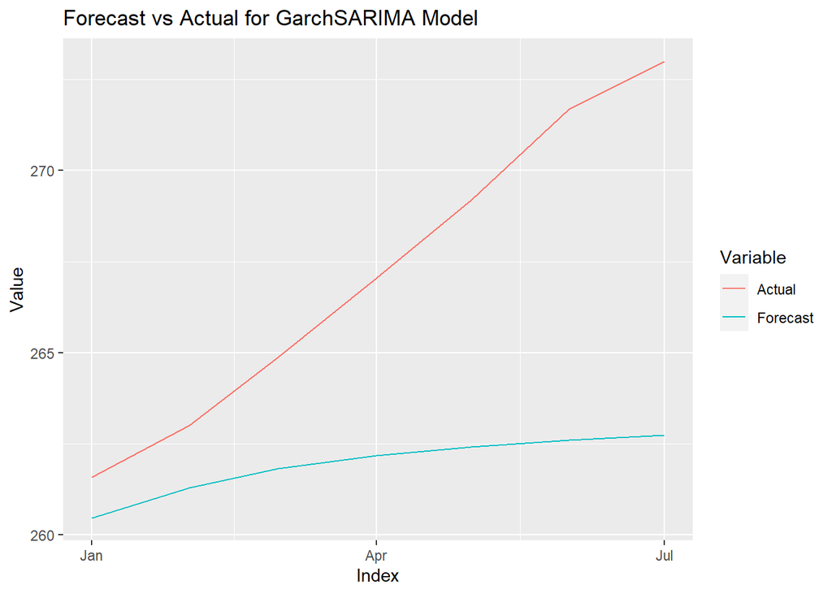

```r
# Create a data frame with forecasted values and actual values
dfgarchsarima <- data.frame(
  Index = test$Yearmon,
  Value = c(forecasted_values, test$CPI),
  Variable = rep(c("Forecast", "Actual"), each = length(forecasted_values))
)

# Plot the data frame
ggplot(dfgarchsarima, aes(x = Index, y = Value, color = Variable)) +
  geom_line() +
  labs(x = "Index", y = "Value", color = "Variable",title = "Forecast vs Actual for GarchSARIMA Model")
```

```r
#plot(sarima_garch_model)

#shapiro.test(residuals(sarima_garch_model))

summary(sarima_garch_model)
```

```
##    Length     Class      Mode
##         1 uGARCHfit        S4
```

# Results (accuracy), learnings from the methodology and future work

I created 6 models in total: 2 ARIMA models, 1 ARFIMA model, 1 Holts-Winter model, 1 ARIMA-GARCH model and 1 SARIMA-GARCH model.Holts-Winter had the best accuracy score looking at the RMSE and MAE scores out of all the models and the forecast was decent enough.

Due to time constraints, I couldn’t fix this issue. In future work, I would have like to try more GARCH models, which are good at handling heteroskedasticity. I would have also liked to bring in another variable such as interest rate to forecast.